# Project 4: Loan Prediction Model

2024-12-05

In Project 1, I focused on cleaning the data, especially the “NA” values that were all over the data. At first, I was not sure how to handle those missing values. But in Project 2, looking at my peer’s work taught me a lesson: first of all, one needs to select the most relevant features to predict loan approval, and most of these should relate to financials. The other variables proved to be less important in this analysis. This realization has made my cleaning of data much easier since I could just use the `na.omit` function, which actually led to an empty dataset if I hadn’t first narrowed down the features.

With this understanding, I will use this strategy in my final Project 4 to enhance efficiency and focus.

# Loading necessary Libraries

```r
# Load necessary library
library(dplyr)
```

```r
library(ggplot2)
library(reshape2)
library(caret)
library(pROC)
library(tidyr)
library(rsample)
library(yardstick)
```

# Data Reading

```r
data <- read.csv("C:\\Users\\prish\\Downloads\\state_GA_actions_taken_1-3.csv", sep = ",", header = T)
```

# Feature Selection

**Data Handling** Lenders must treat all applicants fairly and consistently throughout the lending process, regardless of their personal characteristics. This means evaluating applicants based on their creditworthiness and financial qualifications rather than discriminatory factors[1]. Hence I chose all financial attributes (included sensitive attributes as it’s needed for analysis later, removed whenever needed).

```r
selected_cols <- c('conforming_loan_limit', 'loan_amount','action_taken', 'income','loan_type','loan_purpose','hoepa_status','applicant_credit_score_type','debt_to_income_ratio','derived_sex','derived_ethnicity','derived_race')

selected_data <- data[, selected_cols]

selected_data <- na.omit(selected_data)

# Removing rows where target variable 'action_taken' is missing
selected_data <- selected_data[!is.na(selected_data$action_taken), ]

category_levels <- levels(factor(selected_data$conforming_loan_limit))
selected_data$conforming_loan_limit <- ifelse(selected_data$conforming_loan_limit == "C", 0,1)
```

```r
# Converting all columns to numeric
selected_data_numeric <- selected_data %>%
  mutate(across(everything(), ~ {
    if (is.character(.)) {
      # Converting character to factor, then to numeric
      as.numeric(as.factor(.))
    } else {
      # If already numeric, just return the column
      as.numeric(.)
    }
  }))

# Checking the structure of the new data frame
str(selected_data_numeric)
```

```
## 'data.frame':    274749 obs. of  12 variables:
##  $ conforming_loan_limit      : num  0 1 0 0 0 0 0 0 0 0 ...
##  $ loan_amount                : num  185000 1205000 125000 45000 355000 ...
##  $ action_taken               : num  1 1 1 1 3 1 3 3 3 1 ...
##  $ income                     : num  321 1341 137 97 230 ...
##  $ loan_type                  : num  1 1 1 1 1 1 1 1 1 1 ...
##  $ loan_purpose               : num  1 1 2 2 2 2 4 2 2 31 ...
##  $ hoepa_status               : num  3 2 2 2 3 2 3 3 3 2 ...
##  $ applicant_credit_score_type: num  2 7 2 2 2 9 2 2 2 2 ...
##  $ debt_to_income_ratio       : num  3 1 19 19 2 4 19 2 19 19 ...
##  $ derived_sex                : num  3 3 2 1 3 2 3 2 3 1 ...
##  $ derived_ethnicity          : num  5 5 5 5 1 5 5 5 1 5 ...
##  $ derived_race               : num  9 9 3 9 8 9 4 4 8 9 ...
##  - attr(*, "na.action")= 'omit' Named int [1:19348] 1 2 3 4 5 6 7 8 9 10 ...
##   ..- attr(*, "names")= chr [1:19348] "1" "2" "3" "4" ...
```

# Correlation Anlaysis

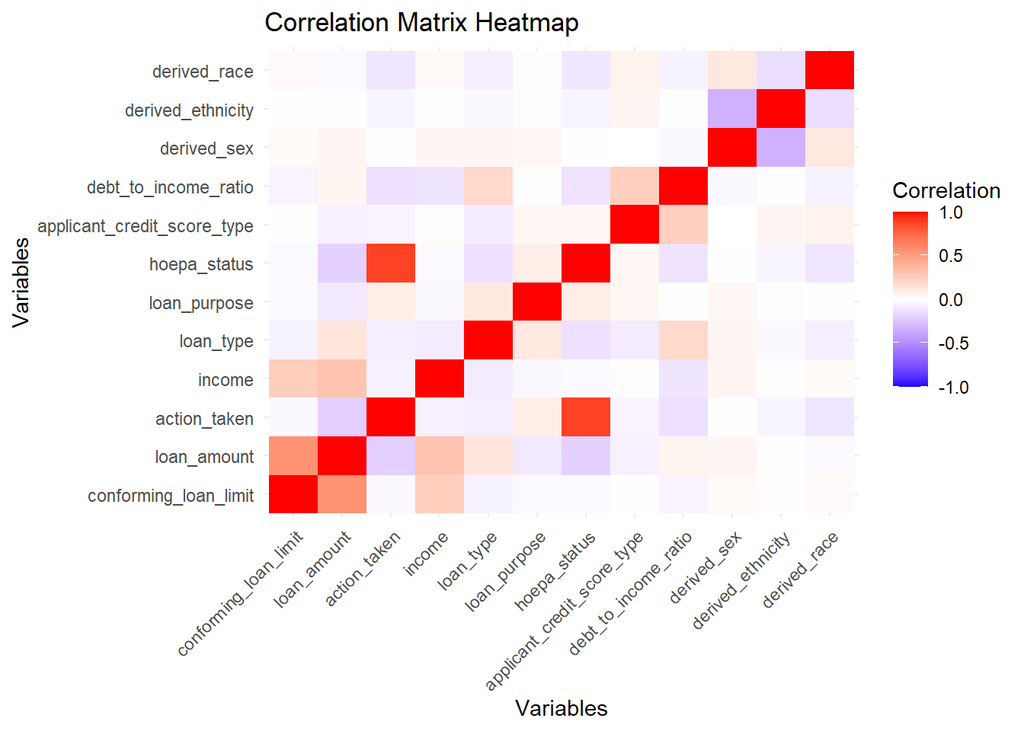

```r
# Calculating the correlation matrix
correlation_matrix <- cor(selected_data_numeric, use = "complete.obs")# Use complete cases only

# Visualizing the correlation matrix using a heatmap
# Melt the correlation matrix for ggplot
correlation_melted <- melt(correlation_matrix)

# Createing a heatmap
ggplot(data = correlation_melted, aes(Var1, Var2, fill = value)) +
  geom_tile() +
  scale_fill_gradient2(low = "blue", high = "red", mid = "white",
                       limit = c(-1, 1), name="Correlation") +
  theme_minimal() +
  theme(axis.text.x = element_text(angle = 45, hjust = 1)) +
  labs(title = "Correlation Matrix Heatmap", x = "Variables", y = "Variables")
```

```r
# Converting action_taken to binary (1 for approved, 0 for denied)
selected_data$action_taken_binary <- ifelse(selected_data$action_taken == 1, 1, 0)

# Removing the original action_taken column and any other unnecessary columns (removing the sensitive attributes for this analysis)
model_data <- selected_data %>%
  select(-action_taken)

# Checking the structure of the new data
str(model_data)
```

```
## 'data.frame':    274749 obs. of  12 variables:
##  $ conforming_loan_limit      : num  0 1 0 0 0 0 0 0 0 0 ...
##  $ loan_amount                : num  185000 1205000 125000 45000 355000 ...
##  $ income                     : int  321 1341 137 97 230 134 58 132 123 232 ...
##  $ loan_type                  : int  1 1 1 1 1 1 1 1 1 1 ...
##  $ loan_purpose               : int  1 1 2 2 2 2 4 2 2 31 ...
##  $ hoepa_status               : int  3 2 2 2 3 2 3 3 3 2 ...
##  $ applicant_credit_score_type: int  2 7 2 2 2 9 2 2 2 2 ...
##  $ debt_to_income_ratio       : chr  "20%-<30%" "<20%" "50%-60%" "50%-60%" ...
##  $ derived_sex                : chr  "Male" "Male" "Joint" "Female" ...
##  $ derived_ethnicity          : chr  "Not Hispanic or Latino" "Not Hispanic or Latino" "Not Hispanic or Latino" "Not Hispanic or Latino" ...
##  $ derived_race               : chr  "White" "White" "Asian" "White" ...
##  $ action_taken_binary        : num  1 1 1 1 0 1 0 0 0 1 ...
##  - attr(*, "na.action")= 'omit' Named int [1:19348] 1 2 3 4 5 6 7 8 9 10 ...
##   ..- attr(*, "names")= chr [1:19348] "1" "2" "3" "4" ...
```

# Data Modeling

I changed my data split from 80-20 to 70-30 for training and testing to get a better evaluation of the model’s performance. In so doing, 30% of the data would be for the test set, hence providing a bigger and more representative sample for testing. This approach aids in evaluating the model’s ability to generalize and minimizes the risk of overfitting. This adjustment gives a better estimate of the model’s performance on new, unseen data, especially when dealing with imbalanced or small datasets.

```r
# Set seed for reproducibility
set.seed(123)

# Creating a train-test split (70% train, 30% test)
train_index <- createDataPartition(model_data$action_taken_binary, p = 0.7, list = FALSE)
train_data <- model_data[train_index, ]
test_data <- model_data[-train_index, ]
```

```r
# Fitting the logistic regression model
log_model <- glm(action_taken_binary ~ ., data = train_data, family = binomial)
# Summary of the model
summary(log_model)
```

```
##
## Call:
## glm(formula = action_taken_binary ~ ., family = binomial, data = train_data)
##
## Coefficients:
##                                                         Estimate Std. Error
## (Intercept)                                            7.862e+01  1.957e+02
## conforming_loan_limit                                 -1.615e+00  1.210e-01
## loan_amount                                            1.765e-06  9.029e-08
## income                                                 8.293e-04  6.479e-05
## loan_type                                             -2.277e+00  7.071e-02
## loan_purpose                                          -7.482e-03  1.116e-03
## hoepa_status                                          -2.625e+01  6.525e+01
## applicant_credit_score_type                           -1.587e-01  4.748e-03
## debt_to_income_ratio>60%                              -3.539e+00  1.165e-01
## debt_to_income_ratio20%-<30%                           3.819e-01  5.360e-02
## debt_to_income_ratio30%-<36%                           4.820e-01  5.452e-02
## debt_to_income_ratio36                                 4.812e-01  9.102e-02
## debt_to_income_ratio37                                 4.285e-01  8.931e-02
## debt_to_income_ratio38                                 5.246e-01  8.567e-02
## debt_to_income_ratio39                                 3.956e-01  8.612e-02
## debt_to_income_ratio40                                 4.132e-01  8.540e-02
## debt_to_income_ratio41                                 5.362e-01  8.269e-02
## debt_to_income_ratio42                                 4.693e-01  7.943e-02
## debt_to_income_ratio43                                 2.277e-01  8.338e-02
## debt_to_income_ratio44                                 3.308e-01  8.007e-02
## debt_to_income_ratio45                                 2.240e-01  8.543e-02
## debt_to_income_ratio46                                 1.262e-01  9.187e-02
## debt_to_income_ratio47                                 1.961e-01  8.906e-02
## debt_to_income_ratio48                                 7.551e-02  8.798e-02
## debt_to_income_ratio49                                 3.048e-01  7.719e-02
## debt_to_income_ratio50%-60%                           -2.178e+00  8.965e-02
## debt_to_income_ratioExempt                             1.783e+02  5.258e+00
## derived_sexJoint                                       2.106e-01  3.919e-02
## derived_sexMale                                        6.503e-02  3.481e-02
## derived_sexSex Not Available                           1.768e-01  6.482e-02
## derived_ethnicityFree Form Text Only                  -8.880e-01  5.639e-01
## derived_ethnicityHispanic or Latino                   -2.013e-02  6.996e-02
## derived_ethnicityJoint                                -1.113e-01  1.189e-01
## derived_ethnicityNot Hispanic or Latino               -2.264e-02  5.523e-02
```

[output cut: 46 more lines]

```
## derived_raceFree Form Text Only                         1.183 0.236888
## derived_raceJoint                                       3.034 0.002410 **
## derived_raceNative Hawaiian or Other Pacific Islander   0.690 0.490415
## derived_raceRace Not Available                          3.750 0.000177 ***
## derived_raceWhite                                       4.269 1.96e-05 ***
## ---
## Signif. codes:  0 '***' 0.001 '**' 0.01 '*' 0.05 '.' 0.1 ' ' 1
##
## (Dispersion parameter for binomial family taken to be 1)
##
##     Null deviance: 228227  on 192324  degrees of freedom
## Residual deviance:  35265  on 192283  degrees of freedom
## AIC: 35349
##
## Number of Fisher Scoring iterations: 20
```

# Logistic Regression Model Summary

The model postulates the relationship between loan amount, income, debt-to-income ratio, and credit score type with regard to the likelihood of loan approval.

**Strong Predictors for Loan Approval**

Key variables include:

- Loan amount: Large loans are positively related to approval rates, probably because large loans are considered to reflect the financial stability of an applicant or the confidence lenders have in the loan.
- Income: Higher income significantly increases the chances of approval, as it means higher repayment capacity.
- Applicant credit score type: A lower credit score significantly reduces the chances of approval, which is expected from the cautious approach of lenders.
- Debt-to-Income Ratio: Ratios above 60% can severely reduce the odds of approval, reflecting lenders’ concerns about the applicant’s ability to manage repayment.

Loan type: Some types of loans are less likely to be approved, which may indicate that lenders have certain preferences or restrictions in place.

These factors agree with the practical criteria that lenders use in making decisions.

# Model Performance Evaluation

```r
# Making predictions on the test set
predicted_probabilities <- predict(log_model, newdata = test_data, type = "response")

# Converting probabilities to binary predictions (threshold = 0.5)
predicted_classes <- ifelse(predicted_probabilities > 0.5, 1, 0)

# Creating a confusion matrix
confusion_matrix <- table(test_data$action_taken_binary, predicted_classes)
print(confusion_matrix)
```

```
##    predicted_classes
##         0     1
##   0 22568   631
##   1  2576 56649
```

**Confusion Matrix**

True Negatives (TN): 22,568 (correctly predicted as denied)

False Positives (FP): 631 (incorrectly predicted as approved)

False Negatives (FN): 2,576 (incorrectly predicted as denied)

True Positives (TP): 56,649 (correctly predicted as approved)

```r
TP <- confusion_matrix[2, 2]  # True Positives
FN <- confusion_matrix[2, 1]  # False Negatives
TN <- confusion_matrix[1, 1]  # True Negatives
FP <- confusion_matrix[1, 2]  # False Positives

# Compute TPR and TNR
TPR <- TP / (TP + FN)  # Sensitivity/Recall
TNR <- TN / (TN + FP)  # Specificity
FPR <- FP / (FP + TN)  # False Positive Rate
FNR <- FN / (FN + TP)  # False Negative Rate
```

```r
TPR
```

```
## [1] 0.9565049
```

```r
TNR
```

```
## [1] 0.9728006
```

```r
FPR
```

```
## [1] 0.02719945
```

```r
FNR
```

```
## [1] 0.04349515
```

```r
# Calculating accuracy
accuracy <- sum(diag(confusion_matrix)) / sum(confusion_matrix)
print(paste("Accuracy:", round(accuracy, 4)))
```

```
## [1] "Accuracy: 0.9611"
```

The model achieved an accuracy of 96.11%. This means that the model classified approximately 96% of the loan applications correctly in the test set, which is a very high accuracy and thus generalizes well overall.

# ROC Curve Analysis

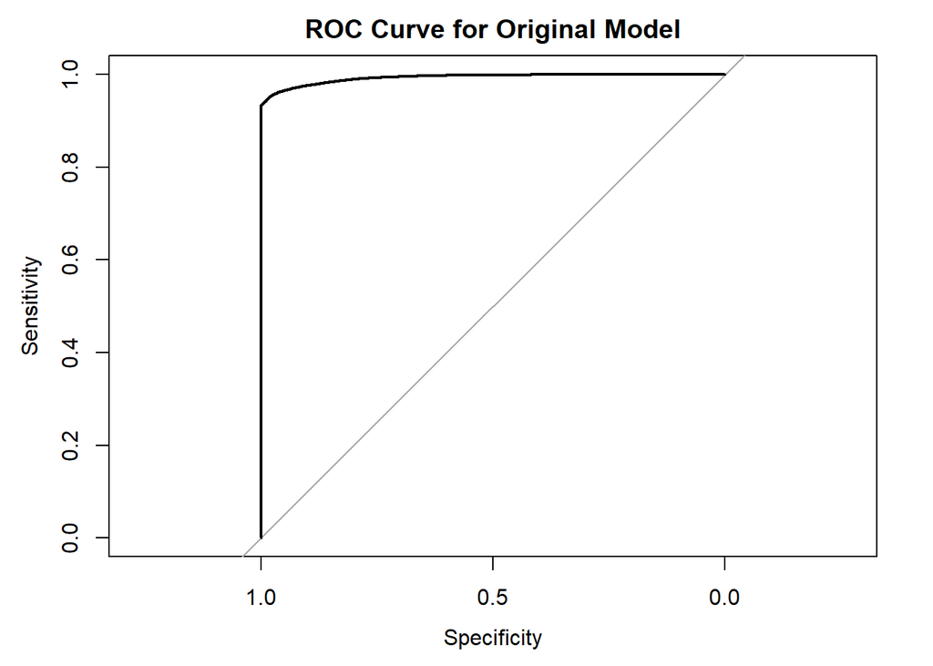

```r
# Calculating ROC curve and AUC
roc_curve <- roc(test_data$action_taken_binary, predicted_probabilities)
auc_value <- auc(roc_curve)

# Plotting ROC curve
plot(roc_curve, main = "ROC Curve for Original Model")
```

```r
print(paste("AUC:", round(auc_value, 4)))
```

```
## [1] "AUC: 0.9928"
```

The ROC curve shows graphically the performance of the model for different thresholds. The AUC is 0.9928, which is very close to 1. This means that the model has an excellent discriminative ability, which means that it can effectively distinguish between approved and denied loan applications.

# Visulisation Analysis

**RACE Proprtions in Original Model**

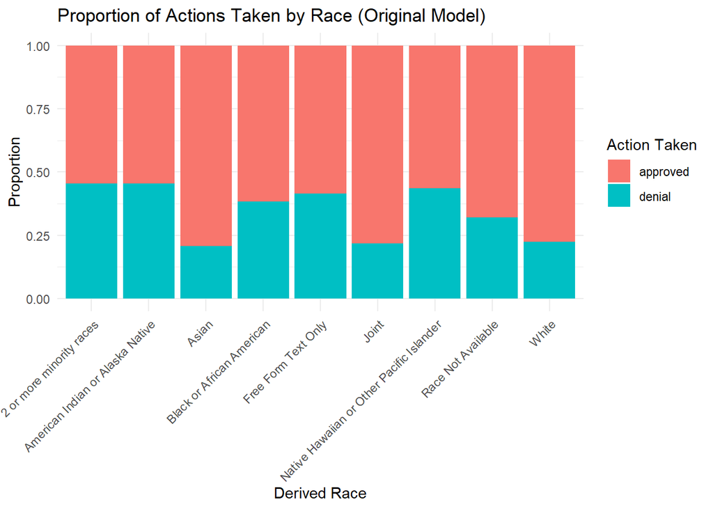

```r
dataa <- selected_data
dataa$action_taken_binary <- as.factor(ifelse(dataa$action_taken_binary == 1, "approved",
                                      ifelse(dataa$action_taken_binary == 0, "denial", NA)))

# Plotting the bar chart
race_original_model <- ggplot(dataa, aes(x = derived_race, fill = action_taken_binary)) +
  geom_bar(position = "fill") +
  labs(
    title = "Proportion of Actions Taken by Race (Original Model)",
    x = "Derived Race",
    y = "Proportion",
    fill = "Action Taken"
  ) +
  theme_minimal() +
  theme(axis.text.x = element_text(angle = 45, hjust = 1))

race_original_model
```

The proportion of approved actions was noticeably higher for certain racial groups, like White and Asian, compared to other groups like Black or African American.

**ETHNICITY Proprtions in Original Model**

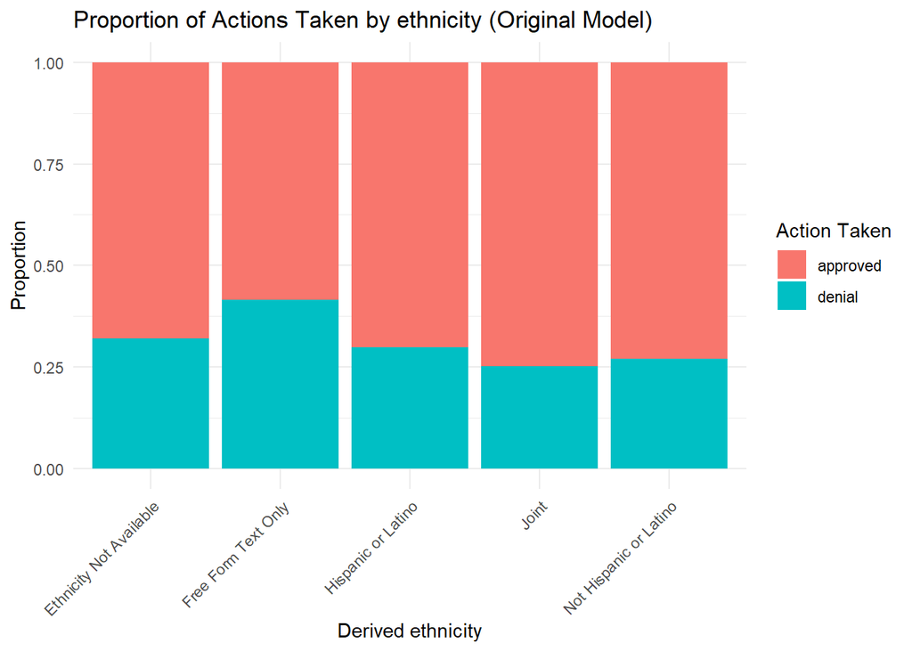

```r
# Plotting the bar chart
ethnicity_original_model <- ggplot(dataa, aes(x = derived_ethnicity, fill = action_taken_binary)) +
  geom_bar(position = "fill") +
  labs(
    title = "Proportion of Actions Taken by ethnicity (Original Model)",
    x = "Derived ethnicity",
    y = "Proportion",
    fill = "Action Taken"
  ) +
  theme_minimal() +
  theme(axis.text.x = element_text(angle = 45, hjust = 1))

ethnicity_original_model
```

The proportion of approved actions was noticeably higher for majority of the ethnicity groups.

**SEX Proprtions in Original Model**

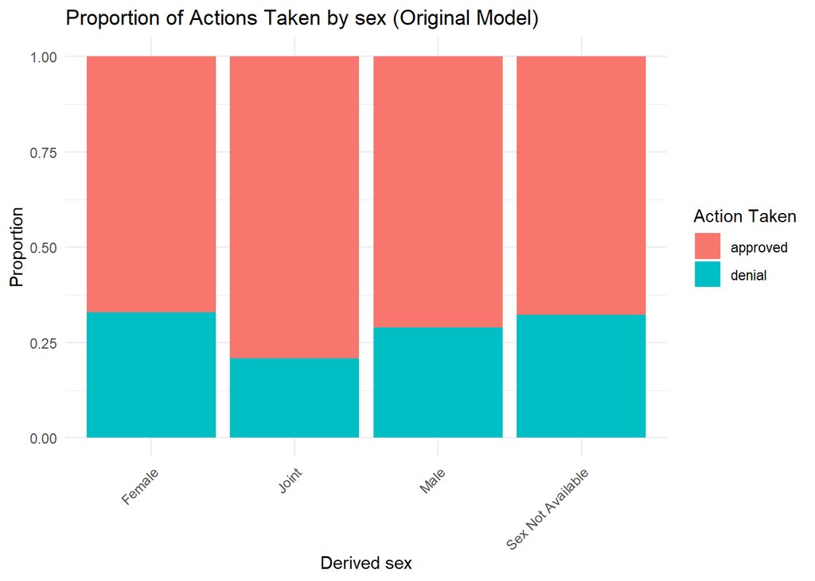

```r
# Plotting the bar chart
sex_original_model <- ggplot(dataa, aes(x = derived_sex, fill = action_taken_binary)) +
  geom_bar(position = "fill") +
  labs(
    title = "Proportion of Actions Taken by sex (Original Model)",
    x = "Derived sex",
    y = "Proportion",
    fill = "Action Taken"
  ) +
  theme_minimal() +
  theme(axis.text.x = element_text(angle = 45, hjust = 1))

sex_original_model
```

# Analysis for Fairness

```r
table(data$denial_reason.1)#(1 = debt_to_income_ratio)
```

```
##
##      1      2      3      4      5      6      7      8      9     10   1111
##  27568   1046  26633   8839   1565   3343   8920     13   6592 202097   7481
```

```r
table(data$denial_reason.2)
```

```
##
##    1    2    3    4    5    6    7    8    9
## 3790  821 3612 2348 1400 1501  831   15 2786
```

```r
table(data$denial_reason.4)
```

```
##
##   1   2   3   4   5   6   7   8   9
##  25   4  66  76  28  32  16   2 270
```

```r
data <- selected_data
data <- data[data$derived_race != "Free Form Text Only", ] #cleaing the data from undesired variables
data <- data[data$derived_ethnicity != "Free Form Text Only",]
```

Analyzing the data, I realized that most loan denials were associated with “debt-to-income ratio,” but class discussions have recently informed me that sometimes models do show bias in the differentiation between demographic groups or genders.

In light of this, my strategy to overcome this is balancing the dataset by randomly selecting individuals in each demographic group so that each demographic group is fairly represented. Using a model created from this balanced dataset, I will compare the results to the results using the original model.

If the two models vary significantly, it would be an indication that the original model may be biased. This approach will enable me to verify whether the predictions are impacted by the imbalances in the data or if they actually reflect the influence of the debt-to-income ratio.

```r
table(data$derived_race)
```

```
##
##                  2 or more minority races
##                                      1014
##          American Indian or Alaska Native
##                                      1052
##                                     Asian
##                                     16303
##                 Black or African American
##                                     67187
##                                     Joint
##                                      4114
## Native Hawaiian or Other Pacific Islander
##                                       437
##                        Race Not Available
##                                     47872
##                                     White
##                                    136495
```

I observed that around 420 is the least of an individual in a race.

# RACE BIASING ANALYSIS

```r
# To achieve a balanced dataset where each race has 420 individual
# Filtering data for each race and sample 420 individuals
data_race_balanced <- bind_rows(
  data %>% filter(derived_race == "2 or more minority races") %>% sample_n(420),
  data %>% filter(derived_race == "American Indian or Alaska Native") %>% sample_n(420),
  data %>% filter(derived_race == "Asian") %>% sample_n(420),
  data %>% filter(derived_race == "Black or African American") %>% sample_n(420),
  data %>% filter(derived_race == "Joint") %>% sample_n(420),
  data %>% filter(derived_race == "Native Hawaiian or Other Pacific Islander") %>% sample_n(420),
  data %>% filter(derived_race == "Race Not Available") %>% sample_n(420),
  data %>% filter(derived_race == "White") %>% sample_n(420)
)

#Calculating the approval rates by race
race_approval_rates_balanced <- prop.table(table(data_race_balanced$derived_race, data_race_balanced$action_taken), 1)
race_approval_rates_balanced
```

```
##
##                                                     1         3
##   2 or more minority races                  0.5214286 0.4785714
##   American Indian or Alaska Native          0.5047619 0.4952381
##   Asian                                     0.7928571 0.2071429
##   Black or African American                 0.6357143 0.3642857
##   Joint                                     0.7952381 0.2047619
##   Native Hawaiian or Other Pacific Islander 0.5666667 0.4333333
##   Race Not Available                        0.6928571 0.3071429
##   White                                     0.7785714 0.2214286
```

```r
race_approval_rates <- prop.table(table(data$derived_race, data$action_taken), 1)
race_approval_rates
```

```
##
##                                                     1         3
##   2 or more minority races                  0.5453649 0.4546351
##   American Indian or Alaska Native          0.5484791 0.4515209
##   Asian                                     0.7937189 0.2062811
##   Black or African American                 0.6169944 0.3830056
##   Joint                                     0.7814779 0.2185221
##   Native Hawaiian or Other Pacific Islander 0.5652174 0.4347826
##   Race Not Available                        0.6797084 0.3202916
##   White                                     0.7761603 0.2238397
```

```r
# Extracting approval rates (action_taken = 1) from both datasets
approval_rates_original_race <- prop.table(table(data$derived_race, data$action_taken), 1)[, "1"]
approval_rates_race_balanced <- prop.table(table(data_race_balanced$derived_race, data_race_balanced$action_taken), 1)[, "1"]

# Calculating differences
approval_rate_differences_race <- approval_rates_race_balanced - approval_rates_original_race

# Combining into a table
comparison_table_race <- data.frame(
  Race = names(approval_rates_original_race),
  Original_Data = round(approval_rates_original_race * 100, 2),
  Balanced_Data = round(approval_rates_race_balanced * 100, 2),
  Difference = round(approval_rate_differences_race * 100, 2)
)
rownames(comparison_table_race) <- comparison_table_race$Race
comparison_table_race$Race <- NULL

# Printing the table
print(comparison_table_race)
```

```
##                                           Original_Data Balanced_Data
## 2 or more minority races                          54.54         52.14
## American Indian or Alaska Native                  54.85         50.48
## Asian                                             79.37         79.29
## Black or African American                         61.70         63.57
## Joint                                             78.15         79.52
## Native Hawaiian or Other Pacific Islander         56.52         56.67
## Race Not Available                                67.97         69.29
## White                                             77.62         77.86
##                                           Difference
## 2 or more minority races                       -2.39
## American Indian or Alaska Native               -4.37
## Asian                                          -0.09
## Black or African American                       1.87
## Joint                                           1.38
## Native Hawaiian or Other Pacific Islander       0.14
## Race Not Available                              1.31
## White                                           0.24
```

**Conclusion**

Most differences are within ±2.5%, which would indicate that the balancing of the dataset resulted in very minor changes in the original approval rates for most groups.

- The largest change is for the American Indian or Alaska Native group, which decreased by 4.37%, indicating a significant drop in approval rates in the balanced dataset.

Other groups saw significant decreases: 2 or more minority races decreased by 2.39%, but still within the margin of acceptable variation.

On the other hand, slight increases in Black or African American of +1.87%, Joint of +1.38%, and Race Not Available with +1.31%, show a fair redistribution without major changes in approval rates.

- In contrast, groups like Asian (-0.09%), Native Hawaiian or Other Pacific Islander (+0.14%), and White (+0.24%) have very small changes, reflecting stability in their approval rates.

The differences are not large overall, which could indicate that balancing might amplify some disparities for specific groups. On the other hand, small changes across most races hint at the fact that the original data wasn’t so biased.

The balancing was done to further validate this finding, and I will use this balanced dataset to create a predictive model and compare its performance with the original model to see if this balancing has any effect.

```r
# Converting action_taken to binary (1 for approved, 0 for denied)
data_race_balanced$action_taken_binary <- ifelse(data_race_balanced$action_taken == 1, 1, 0)

race_model_data <- data_race_balanced %>%
  select(-action_taken,-derived_sex,-derived_ethnicity)
```

```r
set.seed(123)

# Creating a train-test split (70% train, 30% test)
train_index_balanced_race <- createDataPartition(race_model_data$action_taken_binary, p = 0.7, list = FALSE)
train_data_balanced_race <- race_model_data[train_index_balanced_race, ]
test_data_balanced_race <- race_model_data[-train_index_balanced_race, ]
```

```r
# Fit the logistic regression model
log_model_race <- glm(action_taken_binary ~ ., data = train_data_balanced_race, family = binomial)
# Summary of the model
summary(log_model_race)
```

```
##
## Call:
## glm(formula = action_taken_binary ~ ., family = binomial, data = train_data_balanced_race)
##
## Coefficients:
##                                                         Estimate Std. Error
## (Intercept)                                            7.987e+01  1.825e+03
## conforming_loan_limit                                 -2.298e+00  1.680e+00
## loan_amount                                            1.134e-06  9.783e-07
## income                                                 1.566e-03  5.951e-04
## loan_type                                             -1.903e+00  6.025e-01
## loan_purpose                                           4.768e-03  1.084e-02
## hoepa_status                                          -2.676e+01  6.084e+02
## applicant_credit_score_type                           -2.817e-01  5.605e-02
## debt_to_income_ratio>60%                              -2.879e+00  7.427e-01
## debt_to_income_ratio20%-<30%                           8.311e-01  5.024e-01
## debt_to_income_ratio30%-<36%                           3.104e-01  5.578e-01
## debt_to_income_ratio36                                 1.567e-02  9.715e-01
## debt_to_income_ratio37                                -4.703e-01  9.467e-01
## debt_to_income_ratio38                                -5.397e-01  9.554e-01
## debt_to_income_ratio39                                 7.872e-01  8.604e-01
## debt_to_income_ratio40                                 6.528e-01  7.926e-01
## debt_to_income_ratio41                                 7.422e-01  7.756e-01
## debt_to_income_ratio42                                -3.979e-01  8.065e-01
## debt_to_income_ratio43                                -1.177e+00  9.535e-01
## debt_to_income_ratio44                                 1.902e-01  7.954e-01
## debt_to_income_ratio45                                 6.235e-01  9.283e-01
## debt_to_income_ratio46                                -4.799e-01  1.154e+00
## debt_to_income_ratio47                                 5.787e-01  7.335e-01
## debt_to_income_ratio48                                -1.094e+00  9.406e-01
## debt_to_income_ratio49                                 4.166e-02  7.150e-01
## debt_to_income_ratio50%-60%                           -2.245e+00  8.568e-01
## debt_to_income_ratioExempt                             3.142e+02  6.212e+01
## derived_raceAmerican Indian or Alaska Native           3.964e-01  6.334e-01
## derived_raceAsian                                      2.869e+00  5.724e-01
## derived_raceBlack or African American                  8.080e-01  6.660e-01
## derived_raceJoint                                      7.508e-01  6.799e-01
## derived_raceNative Hawaiian or Other Pacific Islander  1.143e+00  6.030e-01
## derived_raceRace Not Available                         1.141e+00  5.989e-01
## derived_raceWhite                                      1.642e+00  6.104e-01
```

[output cut: 30 more lines]

```
## derived_raceBlack or African American                   1.213 0.225042
## derived_raceJoint                                       1.104 0.269439
## derived_raceNative Hawaiian or Other Pacific Islander   1.895 0.058087 .
## derived_raceRace Not Available                          1.905 0.056733 .
## derived_raceWhite                                       2.690 0.007145 **
## ---
## Signif. codes:  0 '***' 0.001 '**' 0.01 '*' 0.05 '.' 0.1 ' ' 1
##
## (Dispersion parameter for binomial family taken to be 1)
##
##     Null deviance: 3014.53  on 2351  degrees of freedom
## Residual deviance:  408.22  on 2318  degrees of freedom
## AIC: 476.22
##
## Number of Fisher Scoring iterations: 20
```

```r
# Making predictions on the test set
predicted_probabilities_race <- predict(log_model_race, newdata = test_data_balanced_race, type = "response")

# Converting probabilities to binary predictions (threshold = 0.5)
predicted_probabilities_race <- ifelse(predicted_probabilities_race > 0.5, 1, 0)

# Creating a confusion matrix
confusion_matrix_race <- table(test_data_balanced_race$action_taken_binary, predicted_probabilities_race)
print(confusion_matrix_race)
```

```
##    predicted_probabilities_race
##       0   1
##   0 338   2
##   1  26 642
```

```r
# Calculating accuracy
accuracy_race <- sum(diag(confusion_matrix_race)) / sum(confusion_matrix_race)
print(paste("Accuracy for balanced race data:", round(accuracy_race, 4)))
```

```
## [1] "Accuracy for balanced race data: 0.9722"
```

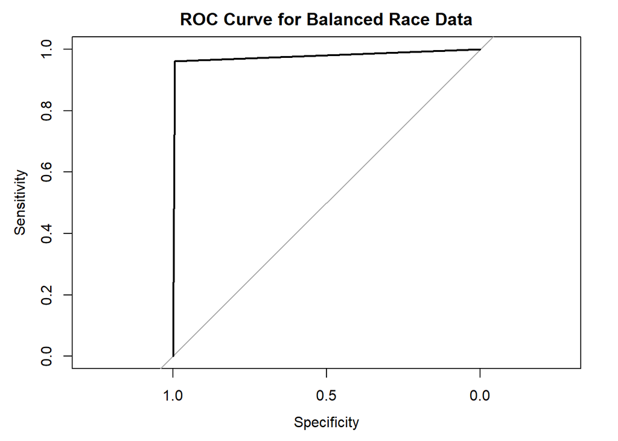

```r
# Calculating ROC curve and AUC
roc_curve_race <- roc(test_data_balanced_race$action_taken_binary, predicted_probabilities_race)
auc_value_race <- auc(roc_curve_race)

# Plotting ROC curve
plot(roc_curve_race, main = "ROC Curve for Balanced Race Data")
```

```r
print(paste("AUC:", round(auc_value_race, 4)))
```

```
## [1] "AUC: 0.9776"
```

# Conclusion on Race and Potential Bias

3. **Balanced Data Implications**:
- The balanced model does not lead to wide changes in predictions, which further supports the fact that the original model is not grossly biased against any particular racial group, even though the balanced model minimizes the effect of possible class imbalances.
4. **Final Assessment**:
- Based on the comparison between the original and balanced models, there is no indication that the original model shows bias against particular racial groups. The consistent approval rates and performance metrics of the model back up this finding.

**Race Balanced Model Proportion Visualization**

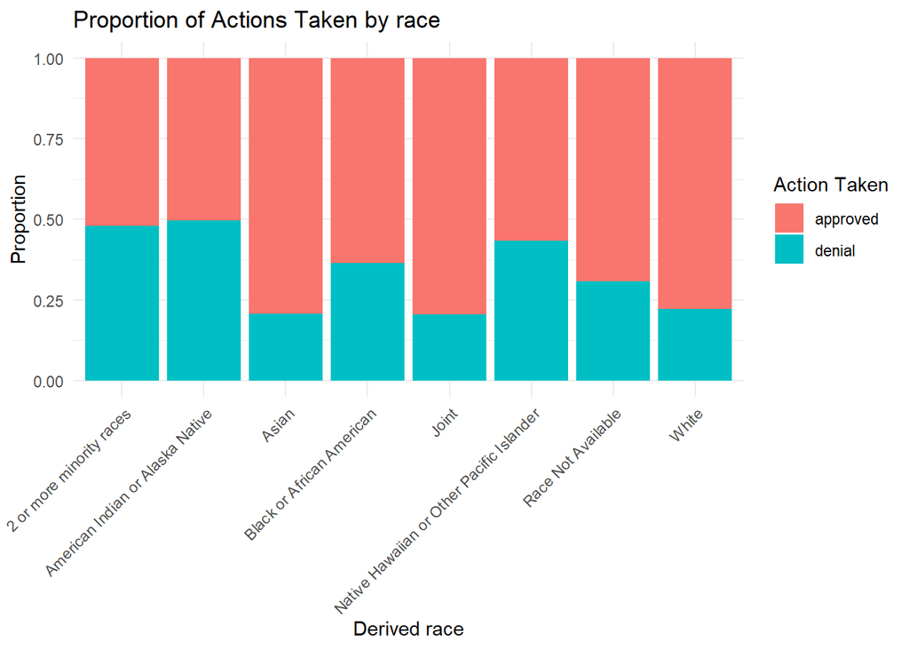

```r
data_race_balanced$action_taken_binary <- as.factor(ifelse(data_race_balanced$action_taken_binary == 1, "approved",
                                      ifelse(data_race_balanced$action_taken_binary == 0, "denial", NA)))
# Plotting the bar chart
race_balanced_model <- ggplot(data_race_balanced, aes(x = derived_race, fill = action_taken_binary)) +
  geom_bar(position = "fill") +
  labs(
    title = "Proportion of Actions Taken by race",
    x = "Derived race",
    y = "Proportion",
    fill = "Action Taken"
  ) +
  theme_minimal() +
  theme(axis.text.x = element_text(angle = 45, hjust = 1))

race_balanced_model
```

The original model and the balanced models exhibited very similar patterns in the proportions of approved and denied actions across the race groups. The balanced models does not reveal any major issues that were not already present in the original model’s outputs.

# ETHNICITY BIAS ANALYSIS

```r
table(data$derived_ethnicity)
```

```
##
## Ethnicity Not Available      Hispanic or Latino                   Joint
##                   46737                   19628                    4669
##  Not Hispanic or Latino
##                  203440
```

I observed that around 4660 is the least of an individual in an ethnicity.

```r
# To achieve a balanced dataset where each ethnicity has 4660 individual
# Filtering data for each ethnicity and sample 4660 individuals
data_ethnicity_balanced <- bind_rows(
  data %>% filter(derived_ethnicity == "Hispanic or Latino") %>% sample_n(4660),
  data %>% filter(derived_ethnicity == "Not Hispanic or Latino") %>% sample_n(4660),
  data %>% filter(derived_ethnicity == "Joint") %>% sample_n(4660),
  data %>% filter(derived_ethnicity == "Ethnicity Not Available") %>% sample_n(4660),
)

#Calculating the approval rates by ethnicity
ethnicity_approval_rates_balanced <- prop.table(table(data_ethnicity_balanced$derived_ethnicity, data_ethnicity_balanced$action_taken), 1)
ethnicity_approval_rates_balanced
```

```
##
##                                   1         3
##   Ethnicity Not Available 0.6804721 0.3195279
##   Hispanic or Latino      0.7034335 0.2965665
##   Joint                   0.7482833 0.2517167
##   Not Hispanic or Latino  0.7263948 0.2736052
```

```r
ethnicity_approval_rates <- prop.table(table(data$derived_ethnicity, data$action_taken), 1)
ethnicity_approval_rates
```

```
##
##                                   1         3
##   Ethnicity Not Available 0.6789054 0.3210946
##   Hispanic or Latino      0.7020583 0.2979417
##   Joint                   0.7483401 0.2516599
##   Not Hispanic or Latino  0.7297631 0.2702369
```

```r
# Extracting approval rates (action_taken = 1) from both datasets
approval_rates_original_ethnicity <- prop.table(table(data$derived_ethnicity, data$action_taken), 1)[, "1"]
approval_rates_ethnicity_balanced <- prop.table(table(data_ethnicity_balanced$derived_ethnicity, data_ethnicity_balanced$action_taken), 1)[, "1"]

# Calculating differences
approval_rate_differences_ethnicity <- approval_rates_ethnicity_balanced - approval_rates_original_ethnicity

# Combining into a table
comparison_table_ethnicity <- data.frame(
  Ethnicity = names(approval_rates_original_ethnicity),
  Original_Data = round(approval_rates_original_ethnicity * 100, 2),
  Balanced_Data = round(approval_rates_ethnicity_balanced * 100, 2),
  Difference = round(approval_rate_differences_ethnicity * 100, 2)
)
rownames(comparison_table_ethnicity) <- comparison_table_ethnicity$Race
comparison_table_ethnicity$Ethnicity <- NULL

# Printing the table
print(comparison_table_ethnicity)
```

```
##   Original_Data Balanced_Data Difference
## 1         67.89         68.05       0.16
## 2         70.21         70.34       0.14
## 3         74.83         74.83      -0.01
## 4         72.98         72.64      -0.34
```

**Conclusion**

In general, the differences between the original and balanced datasets are not very significant, which might mean that the balancing process did not introduce significant bias into the model.

Further to validate this finding, I will create a predictive model using the balanced dataset and compare its performance against the original model to determine if the balancing has any effect on the results.

```r
# Converting action_taken to binary (1 for approved, 0 for denied)
data_ethnicity_balanced$action_taken_binary <- ifelse(data_ethnicity_balanced$action_taken == 1, 1, 0)

ethnicity_model_data <- data_ethnicity_balanced %>%
  select(-action_taken,-derived_sex,-derived_race)
```

```r
set.seed(123)

# Creating a train-test split (70% train, 30% test)
train_index_balanced_ethnicity <- createDataPartition(ethnicity_model_data$action_taken_binary, p = 0.7, list = FALSE)
train_data_balanced_ethnicity <- ethnicity_model_data[train_index_balanced_ethnicity, ]
test_data_balanced_ethnicity <- ethnicity_model_data[-train_index_balanced_ethnicity, ]
```

```r
# Fitting the logistic regression model
log_model_ethnicity <- glm(action_taken_binary ~ ., data = train_data_balanced_ethnicity, family = binomial)
# Summary of the model
summary(log_model_ethnicity)
```

```
##
## Call:
## glm(formula = action_taken_binary ~ ., family = binomial, data = train_data_balanced_ethnicity)
##
## Coefficients:
##                                           Estimate Std. Error z value Pr(>|z|)
## (Intercept)                              8.305e+01  7.294e+02   0.114  0.90935
## conforming_loan_limit                   -2.633e+00  5.011e-01  -5.254 1.49e-07
## loan_amount                              3.108e-06  3.550e-07   8.754  < 2e-16
## income                                   4.323e-05  4.018e-05   1.076  0.28198
## loan_type                               -2.766e+00  3.220e-01  -8.592  < 2e-16
## loan_purpose                            -1.413e-02  4.587e-03  -3.080  0.00207
## hoepa_status                            -2.716e+01  2.431e+02  -0.112  0.91105
## applicant_credit_score_type             -1.507e-01  1.820e-02  -8.284  < 2e-16
## debt_to_income_ratio>60%                -4.918e+00  7.328e-01  -6.711 1.93e-11
## debt_to_income_ratio20%-<30%             3.742e-01  2.067e-01   1.811  0.07018
## debt_to_income_ratio30%-<36%             8.327e-02  2.147e-01   0.388  0.69817
## debt_to_income_ratio36                   3.114e-01  3.387e-01   0.919  0.35791
## debt_to_income_ratio37                   4.355e-01  3.107e-01   1.402  0.16095
## debt_to_income_ratio38                   3.715e-01  3.388e-01   1.097  0.27280
## debt_to_income_ratio39                   2.767e-02  3.650e-01   0.076  0.93957
## debt_to_income_ratio40                  -9.919e-02  3.503e-01  -0.283  0.77706
## debt_to_income_ratio41                   9.076e-01  3.024e-01   3.002  0.00269
## debt_to_income_ratio42                   3.968e-01  3.051e-01   1.301  0.19342
## debt_to_income_ratio43                   3.195e-01  3.190e-01   1.001  0.31666
## debt_to_income_ratio44                   3.688e-01  2.791e-01   1.321  0.18634
## debt_to_income_ratio45                   2.073e-01  3.456e-01   0.600  0.54849
## debt_to_income_ratio46                   8.276e-02  3.446e-01   0.240  0.81020
## debt_to_income_ratio47                   1.994e-01  3.366e-01   0.592  0.55373
## debt_to_income_ratio48                  -2.010e-01  3.604e-01  -0.558  0.57703
## debt_to_income_ratio49                   3.363e-02  3.109e-01   0.108  0.91387
## debt_to_income_ratio50%-60%             -2.429e+00  3.481e-01  -6.978 2.99e-12
## debt_to_income_ratioExempt               1.691e+02  2.014e+01   8.395  < 2e-16
## derived_ethnicityHispanic or Latino      6.242e-02  1.465e-01   0.426  0.67010
## derived_ethnicityJoint                  -1.580e-02  1.505e-01  -0.105  0.91640
## derived_ethnicityNot Hispanic or Latino  9.573e-03  1.482e-01   0.065  0.94850
##
## (Intercept)
## conforming_loan_limit                   ***
## loan_amount                             ***
```

[output cut: 22 more lines]

```
## debt_to_income_ratio50%-60%             ***
## debt_to_income_ratioExempt              ***
## derived_ethnicityHispanic or Latino
## derived_ethnicityJoint
## derived_ethnicityNot Hispanic or Latino
## ---
## Signif. codes:  0 '***' 0.001 '**' 0.01 '*' 0.05 '.' 0.1 ' ' 1
##
## (Dispersion parameter for binomial family taken to be 1)
##
##     Null deviance: 15648.9  on 13047  degrees of freedom
## Residual deviance:  2282.5  on 13018  degrees of freedom
## AIC: 2342.5
##
## Number of Fisher Scoring iterations: 20
```

```r
# Making predictions on the test set
predicted_probabilities_ethnicity <- predict(log_model_ethnicity, newdata = test_data_balanced_ethnicity, type = "response")

# Converting probabilities to binary predictions (threshold = 0.5)
predicted_probabilities_ethnicity <- ifelse(predicted_probabilities_ethnicity > 0.5, 1, 0)

# Creating a confusion matrix
confusion_matrix_ethnicity <- table(test_data_balanced_ethnicity$action_taken_binary, predicted_probabilities_ethnicity)
print(confusion_matrix_ethnicity)
```

```
##    predicted_probabilities_ethnicity
##        0    1
##   0 1532   39
##   1  216 3805
```

```r
# Calculating accuracy
accuracy_ethnicity <- sum(diag(confusion_matrix_ethnicity)) / sum(confusion_matrix_ethnicity)
print(paste("Accuracy for balanced ethnicity data:", round(accuracy_ethnicity, 4)))
```

```
## [1] "Accuracy for balanced ethnicity data: 0.9544"
```

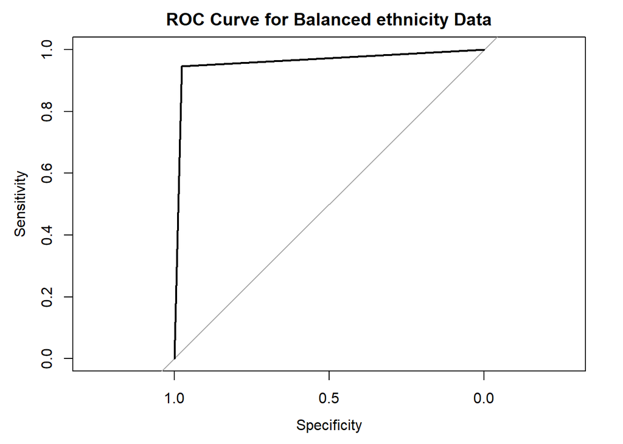

```r
# Calculating ROC curve and AUC
roc_curve_ethnicity <- roc(test_data_balanced_ethnicity$action_taken_binary, predicted_probabilities_ethnicity)
auc_value_ethnicity <- auc(roc_curve_ethnicity)

# Plotting ROC curve
plot(roc_curve_ethnicity, main = "ROC Curve for Balanced ethnicity Data")
```

```r
print(paste("AUC:", round(auc_value_ethnicity, 4)))
```

```
## [1] "AUC: 0.9607"
```

# Conclusion on Ethnicity and Potential Bias:

1. **Model Behavior w.r.t. Ethnicity**:
- The balanced model has slightly better performance metrics to indicate that ethnic group imbalances may be conducive to a more fair and robust model without seriously affecting the predictive capabilities of the original model.
2. **Approval Rates Across Ethnicity Groups**:
- Approval rates across different ethnicities are fairly consistent between the original and balanced datasets, which would imply that there is no substantial ethnic bias in the original model.
3. **Final Assessment**:
- It also doesn’t show any strong evidence of bias against specific ethnic groups in the original model.
- Nonetheless, rebalancing this further for imbalances in data will further enhance fairness and make sure this model stays robust and equitable for all ethnicities. In so doing, one is actively working to minimize potential bias and build trust in said system.

**Ethnicity Balanced Model Proportion Visualization**

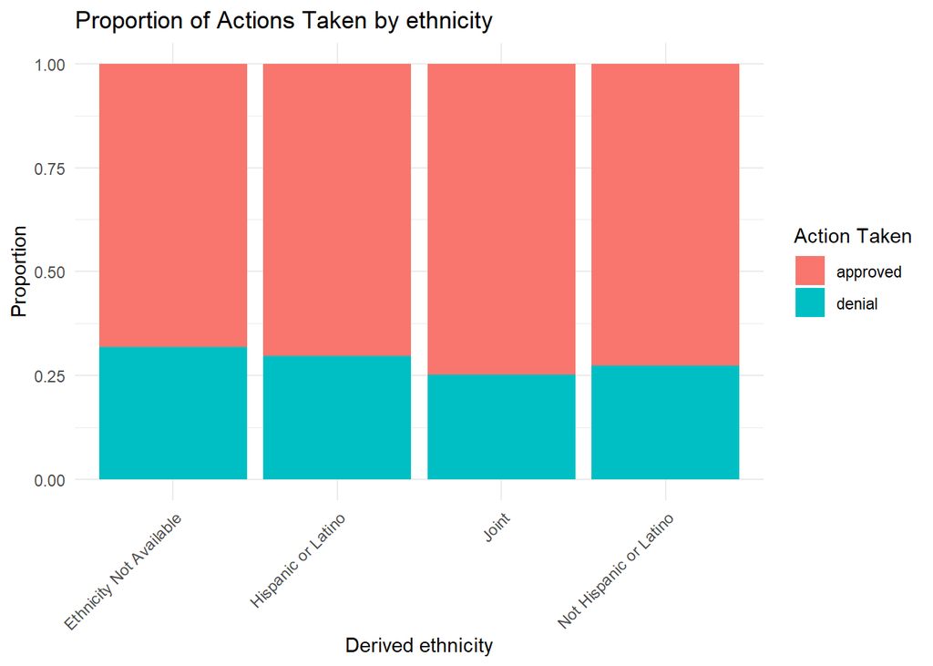

```r
data_ethnicity_balanced$action_taken_binary <- as.factor(ifelse(data_ethnicity_balanced$action_taken_binary == 1, "approved",
                                                           ifelse(data_ethnicity_balanced$action_taken_binary == 0, "denial", NA)))
# Plotting the bar chart
ethnicity_balanced_model <- ggplot(data_ethnicity_balanced, aes(x = derived_ethnicity, fill = action_taken_binary)) +
  geom_bar(position = "fill") +
  labs(
    title = "Proportion of Actions Taken by ethnicity",
    x = "Derived ethnicity",
    y = "Proportion",
    fill = "Action Taken"
  ) +
  theme_minimal() +
  theme(axis.text.x = element_text(angle = 45, hjust = 1))

ethnicity_balanced_model
```

The original model and the balanced models exhibited very similar patterns in the proportions of approved and denied actions across ethnic groups. The balanced models does not reveal any major issues that were not already present in the original model’s outputs.

# Sex BIAS ANALYSIS

```r
table(data$derived_sex)
```

```
##
##            Female             Joint              Male Sex Not Available
##             75651             76528             99431             22864
```

I observed the least value and choose to take 22800 samples of each group

```r
# To achieve a balanced dataset where each sex has 4660 individual
# Filtering data for each sex and sample 4660 individuals
data_sex_balanced <- bind_rows(
  data %>% filter(derived_sex == "Female") %>% sample_n(22800),
  data %>% filter(derived_sex == "Male") %>% sample_n(22800),
  data %>% filter(derived_sex == "Joint") %>% sample_n(22800),
  data %>% filter(derived_sex == "Sex Not Available") %>% sample_n(22800),
)

#Calculating the approval rates by sex
sex_approval_rates_balanced <- prop.table(table(data_sex_balanced$derived_sex, data_sex_balanced$action_taken), 1)
sex_approval_rates_balanced
```

```
##
##                             1         3
##   Female            0.6698684 0.3301316
##   Joint             0.7907456 0.2092544
##   Male              0.7137281 0.2862719
##   Sex Not Available 0.6781140 0.3218860
```

```r
sex_approval_rates <- prop.table(table(data$derived_sex, data$action_taken), 1)
sex_approval_rates
```

```
##
##                             1         3
##   Female            0.6705529 0.3294471
##   Joint             0.7906387 0.2093613
##   Male              0.7114079 0.2885921
##   Sex Not Available 0.6777904 0.3222096
```

```r
# Extracting approval rates (action_taken = 1) from both datasets
approval_rates_original_sex <- prop.table(table(data$derived_sex, data$action_taken), 1)[, "1"]
approval_rates_sex_balanced <- prop.table(table(data_sex_balanced$derived_sex, data_sex_balanced$action_taken), 1)[, "1"]

# Calculating differences
approval_rate_differences_sex <- approval_rates_sex_balanced - approval_rates_original_sex

# Combining into a table
comparison_table_sex <- data.frame(
  sex = names(approval_rates_original_sex),
  Original_Data = round(approval_rates_original_sex * 100, 2),
  Balanced_Data = round(approval_rates_sex_balanced * 100, 2),
  Difference = round(approval_rate_differences_sex * 100, 2)
)
rownames(comparison_table_sex) <- comparison_table_sex$Race
comparison_table_sex$sex <- NULL

# Printing the table
print(comparison_table_sex)
```

```
##   Original_Data Balanced_Data Difference
## 1         67.06         66.99      -0.07
## 2         79.06         79.07       0.01
## 3         71.14         71.37       0.23
## 4         67.78         67.81       0.03
```

**Conclusion**

- Most of the differences in approval rates by sex are within ±0.25%, indicating that balancing has barely caused deviations from the original dataset.
- The most outstanding change is in the Male group, which changed by +0.23%, indicating that the balanced dataset had a slightly higher approval rate.
- On the other hand, the Female group has seen a slight decline of -0.07%, while the Sex Not Available category is up by +0.03%.
- The category of Joint shows practically no variation, at +0.01%.

These small differences imply that the balancing process has not significantly impacted the distribution of approval rates among the sex groups. That is, the original data is fairly balanced, and there could be less potential bias within the dataset.

The predictive model in this work uses a balanced dataset that I will create and will compare with the original model for the verification of whether such balancing makes any difference in the result.

```r
# Converting action_taken to binary (1 for approved, 0 for denied)
data_sex_balanced$action_taken_binary <- ifelse(data_sex_balanced$action_taken == 1, 1, 0)

sex_model_data <- data_sex_balanced %>%
  select(-action_taken,-derived_ethnicity,-derived_race)
```

```r
set.seed(123)

# Creating a train-test split (70% train, 30% test)
train_index_balanced_sex <- createDataPartition(sex_model_data$action_taken_binary, p = 0.7, list = FALSE)
train_data_balanced_sex <- sex_model_data[train_index_balanced_sex, ]
test_data_balanced_sex <- sex_model_data[-train_index_balanced_sex, ]
```

```r
# Fitting the logistic regression model
log_model_sex <- glm(action_taken_binary ~ ., data = train_data_balanced_sex, family = binomial)
# Summary of the model
summary(log_model_sex)
```

```
##
## Call:
## glm(formula = action_taken_binary ~ ., family = binomial, data = train_data_balanced_sex)
##
## Coefficients:
##                                Estimate Std. Error z value Pr(>|z|)
## (Intercept)                   8.103e+01  3.386e+02   0.239  0.81083
## conforming_loan_limit        -1.758e+00  2.141e-01  -8.208 2.25e-16 ***
## loan_amount                   1.819e-06  1.572e-07  11.573  < 2e-16 ***
## income                        1.221e-03  1.226e-04   9.956  < 2e-16 ***
## loan_type                    -2.549e+00  1.312e-01 -19.425  < 2e-16 ***
## loan_purpose                 -1.397e-02  1.869e-03  -7.473 7.83e-14 ***
## hoepa_status                 -2.658e+01  1.129e+02  -0.236  0.81382
## applicant_credit_score_type  -1.533e-01  7.894e-03 -19.414  < 2e-16 ***
## debt_to_income_ratio>60%     -3.725e+00  2.154e-01 -17.295  < 2e-16 ***
## debt_to_income_ratio20%-<30%  2.905e-01  8.906e-02   3.262  0.00111 **
## debt_to_income_ratio30%-<36%  3.994e-01  9.115e-02   4.382 1.18e-05 ***
## debt_to_income_ratio36        2.038e-01  1.576e-01   1.293  0.19605
## debt_to_income_ratio37        2.906e-01  1.511e-01   1.923  0.05454 .
## debt_to_income_ratio38        5.818e-01  1.454e-01   4.002 6.29e-05 ***
## debt_to_income_ratio39        2.291e-01  1.471e-01   1.557  0.11944
## debt_to_income_ratio40        4.059e-01  1.381e-01   2.940  0.00328 **
## debt_to_income_ratio41        6.130e-01  1.367e-01   4.485 7.28e-06 ***
## debt_to_income_ratio42        3.518e-01  1.371e-01   2.565  0.01031 *
## debt_to_income_ratio43        1.766e-01  1.397e-01   1.264  0.20612
## debt_to_income_ratio44        9.438e-02  1.358e-01   0.695  0.48720
## debt_to_income_ratio45        2.921e-01  1.364e-01   2.141  0.03229 *
## debt_to_income_ratio46        6.479e-04  1.587e-01   0.004  0.99674
## debt_to_income_ratio47        1.527e-01  1.501e-01   1.017  0.30906
## debt_to_income_ratio48       -4.939e-03  1.495e-01  -0.033  0.97364
## debt_to_income_ratio49        3.599e-01  1.251e-01   2.877  0.00401 **
## debt_to_income_ratio50%-60%  -2.136e+00  1.470e-01 -14.533  < 2e-16 ***
## debt_to_income_ratioExempt    1.720e+02  8.741e+00  19.677  < 2e-16 ***
## derived_sexJoint              2.242e-01  6.832e-02   3.281  0.00103 **
## derived_sexMale               1.424e-01  6.455e-02   2.207  0.02734 *
## derived_sexSex Not Available  1.479e-01  6.511e-02   2.271  0.02313 *
## ---
## Signif. codes:  0 '***' 0.001 '**' 0.01 '*' 0.05 '.' 0.1 ' ' 1
##
## (Dispersion parameter for binomial family taken to be 1)
##
##     Null deviance: 76513  on 63839  degrees of freedom
## Residual deviance: 12313  on 63810  degrees of freedom
## AIC: 12373
##
## Number of Fisher Scoring iterations: 20
```

```r
# Making predictions on the test set
predicted_probabilities_sex <- predict(log_model_sex, newdata = test_data_balanced_sex, type = "response")

# Converting probabilities to binary predictions (threshold = 0.5)
predicted_probabilities_sex <- ifelse(predicted_probabilities_sex > 0.5, 1, 0)

# Creating a confusion matrix
confusion_matrix_sex <- table(test_data_balanced_sex$action_taken_binary, predicted_probabilities_sex)
print(confusion_matrix_sex)
```

```
##    predicted_probabilities_sex
##         0     1
##   0  7674   181
##   1  1042 18463
```

```r
# Calculating accuracy
accuracy_sex <- sum(diag(confusion_matrix_sex)) / sum(confusion_matrix_sex)
print(paste("Accuracy for balanced sex data:", round(accuracy_sex, 4)))
```

```
## [1] "Accuracy for balanced sex data: 0.9553"
```

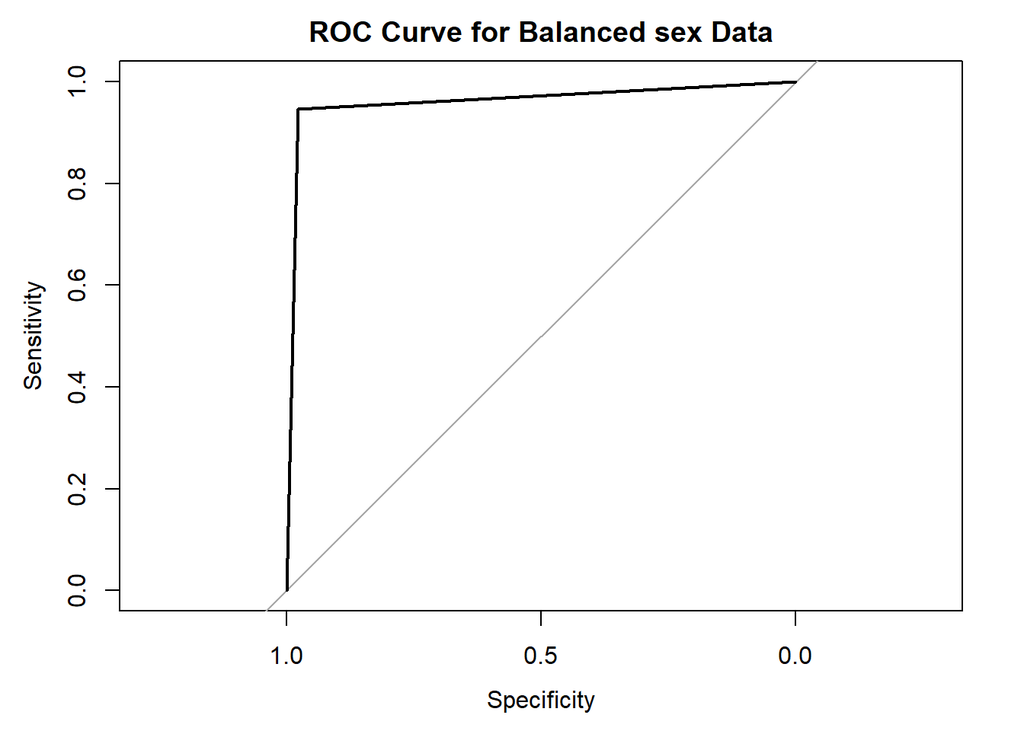

```r
# Calculating ROC curve and AUC
roc_curve_sex <- roc(test_data_balanced_sex$action_taken_binary, predicted_probabilities_sex)
auc_value_sex <- auc(roc_curve_sex)

# Plotting ROC curve
plot(roc_curve_sex, main = "ROC Curve for Balanced sex Data")
```

```r
print(paste("AUC:", round(auc_value_sex, 4)))
```

```
## [1] "AUC: 0.9618"
```